# Praca domowa 3 - testy poprawności knn()

Szymon Adach

Kwietnia, 2017

Referencyjna funkcja ma postać:

```r
knn_do_porownan <- function(X, y, Z, k, p=2) {
    # działa tylko dla "małych" p
    stopifnot(p <= 10)
    moda <- function(u) {
        ut <- table(u)
        ut <- ut[ut == max(ut)]
        if (length(ut) == 1) names(ut[1])
        else names(ut[sample(length(ut), 1)])
        # tu jest if, bo sample(jedna_wartosc) dziala inaczej niz chcemy
    }

    # porównaj tę implementację ze swoją
    X <- t(X)
    Z <- t(Z)
    yc <- as.character(y)
    r <- sapply(1:ncol(Z), function(i) {
        d <- colSums(abs(X-Z[,i])^p) # odleglosci (bez pierwiastka stopnia p) - Z[,i] vs kazdy z X
        moda(yc[order(d)[1:k]])
    })
    factor(r, levels=levels(y)) # zachowujemy zgodnosc z oryginalnym czynnikiem y
}
```

Ze względu na wykorzystanie losowości w przypadku, gdy jest kilka wartości-kandydatów do miana dominanty, mogą wystąpić rozbieżności pomiędzy wynikami referencyjnej funkcji oraz funkcji `knn()`. Zbiory do testów zamieszczone są na stronie [gagolewski.com](http://www.gagolewski.com/resources/data/ordinal-regression/) w postaci plików csv. Wykorzystałem zestawy:

- abalone
- skill
- glass

# 1 Abalone

## 1.1 k = 1, p = 2

Zbiór uczący i testowy są takie same - w tym przypadku dla $k=1$ nie powinny występować rozbieżności między etykietami wejściowymi a obliczonymi (wyjątkowo zbiory są z $\mathbb{R}^n$).

Funkcja referencyjna:

```r
f1 <- knn_do_porownan(X, y, X, 1, 2)
head(f1, n=100)
```

```
##   [1] 8 2 4 5 2 3 8 8 4 8 8 5 6 5 5 7 2 5 2 4 6 5 7 4 5 6 6 7 8 6 5 8 8 8 7
##  [36] 3 8 3 6 4 4 8 1 1 1 2 4 2 1 4 3 2 5 5 2 3 3 3 1 2 2 4 5 2 3 3 7 7 5 1
##  [71] 7 3 8 6 7 8 4 5 6 8 4 7 8 8 8 7 7 5 4 7 8 7 7 5 8 8 4 3 2 5
## Levels: 1 2 3 4 5 6 7 8
```

Liczba różnic pomiędzy wynikiem $w$ a poprawnymi etykietami $y$ wynosi 0.

Własna implementacja:

```r
f2 <- knn(X, y, X, 1, 2)
head(f2, n=100)
```

```
##   [1] 8 2 4 5 2 3 8 8 4 8 8 5 6 5 5 7 2 5 2 4 6 5 7 4 5 6 6 7 8 6 5 8 8 8 7
##  [36] 3 8 3 6 4 4 8 1 1 1 2 4 2 1 4 3 2 5 5 2 3 3 3 1 2 2 4 5 2 3 3 7 7 5 1
##  [71] 7 3 8 6 7 8 4 5 6 8 4 7 8 8 8 7 7 5 4 7 8 7 7 5 8 8 4 3 2 5
## Levels: 1 2 3 4 5 6 7 8
```

Liczba różnic pomiędzy wynikiem $w$ a poprawnymi etykietami $y$ wynosi 0.

Czy wyniki funkcji są takie same: TRUE

Wyniki funkcji różnią się na 0 pozycjach (0% całości)

## 1.2 k = 3, p = 7

Funkcja referencyjna:

```r
f1 <- knn_do_porownan(X1, y, Z, 3, 7)
f1
```

```
##   [1] 1 1 8 5 1 7 4 8 7 2 2 5 4 7 1 7 3 4 7 5 1 2 1 3 6 3 1 6 2 3 5 4 2 8 7
##  [36] 5 2 1 7 4 2 5 3 6 4 4 1 6 8 7 7 3 5 1 5 4 3 8 1 2 8 8 7 8 8 2 4 4 2 5
##  [71] 7 2 5 7 1 3 8 6 5 4 8 8 8 3 2 7 3 3 8 4 4 2 5 1 3 7 2 1 7 2
## Levels: 1 2 3 4 5 6 7 8
```

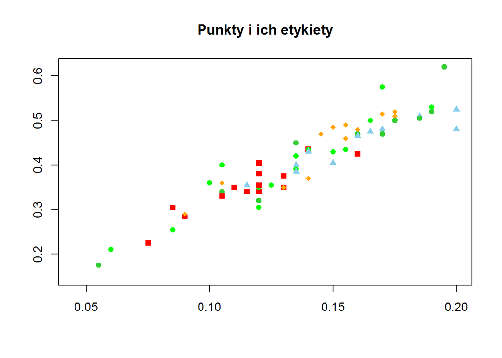

Własna implementacja:

```r
f2 <- knn(X1, y, Z, 3, 7)
f2
```

```
##   [1] 6 1 4 5 4 2 3 4 7 5 4 5 6 3 5 6 7 4 7 3 5 5 5 5 6 5 4 6 1 3 4 2 2 4 4
##  [36] 4 4 3 1 3 5 5 4 5 3 3 3 6 4 2 6 7 1 8 4 7 3 8 8 4 3 4 5 4 5 8 7 1 3 4
##  [71] 8 2 5 7 5 6 4 5 5 8 7 5 5 7 8 7 6 4 8 5 5 5 4 6 3 4 8 5 4 2
## Levels: 1 2 3 4 5 6 7 8
```

Czy wyniki funkcji są takie same: FALSE

Wyniki funkcji różnią się na 78 pozycjach (78% całości)

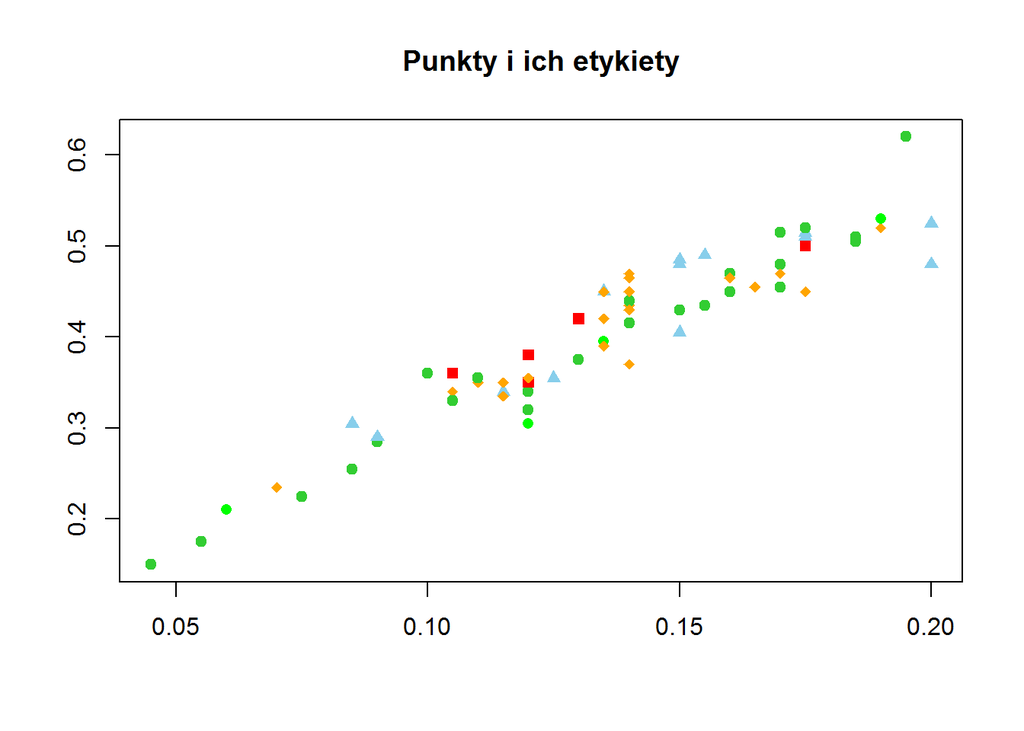

## 1.3 k = 9, p = 9

Funkcja referencyjna:

```r
f1 <- knn_do_porownan(X1, y, Z, 9, 9)
f1
```

```
##  [1] 3 8 6 7 1 7 4 3 5 5 5 8 4 5 6 6 5 6 6 1 1 8 6 5 4 7 2 3 2 1 4 2 8 4 6
## [36] 5 8 1 1 1 8 2 4 3 2 6 3 8 5 6 1 7 7 5 7 5 6 6 8 4 7 8 4 4 1 7 6 3 8 6
## Levels: 1 2 3 4 5 6 7 8
```

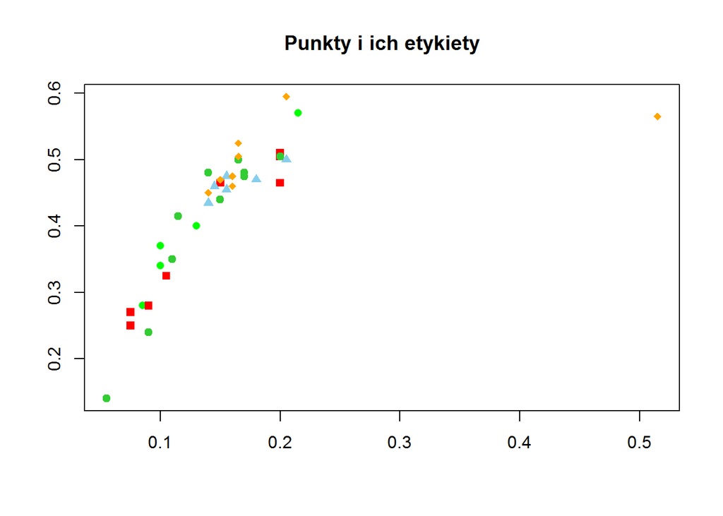

Własna implementacja:

```r
f2 <- knn(X1, y, Z, 9, 9)
f2
```

```
##  [1] 3 8 6 7 1 5 4 6 5 6 4 5 4 5 7 5 7 6 6 1 8 8 3 1 4 3 4 4 2 4 3 2 8 3 4
## [36] 2 8 5 1 1 8 2 4 3 2 4 3 8 5 6 5 1 2 6 3 5 4 2 6 4 7 8 5 5 1 7 6 3 6 5
## Levels: 1 2 3 4 5 6 7 8
```

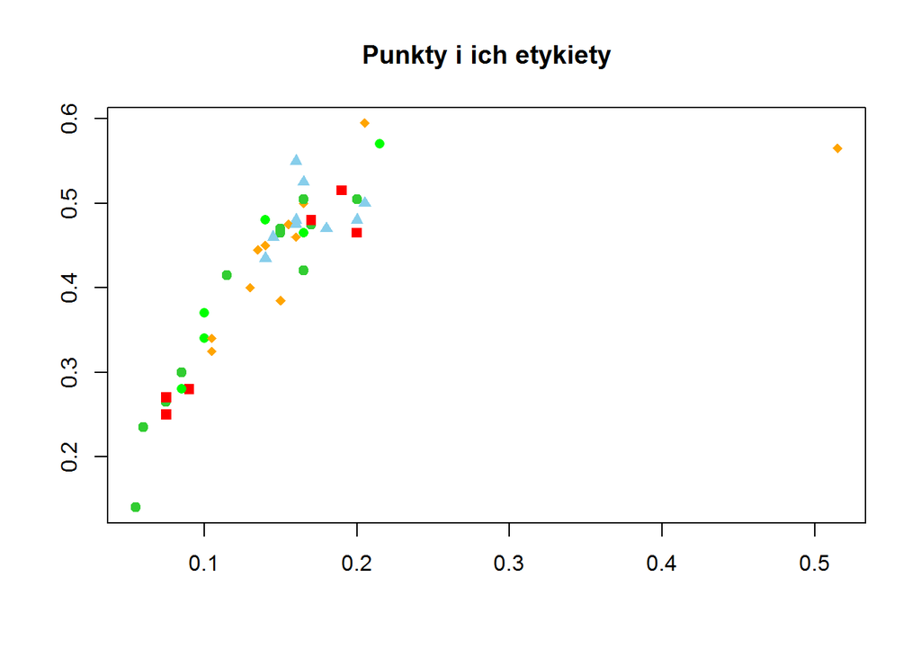

Czy wyniki funkcji są takie same: FALSE

Wyniki funkcji różnią się na 33 pozycjach (47.1428571% całości)

# 2 Skill

## 2.1 k = 1, p = 2

Zbiór uczący i testowy są takie same - w tym przypadku dla $k=1$ nie powinny występować rozbieżności między etykietami wejściowymi a obliczonymi (wyjątkowo zbiory są z $\mathbb{R}^n$).

Funkcja referencyjna:

```r
f1 <- knn_do_porownan(X, y, X, 1, 2)
head(f1, n=100)
```

```
##   [1] 5 5 4 3 3 2 1 7 4 4 3 4 3 3 5 5 4 5 5 4 5 6 5 5 4 4 6 5 5 6 3 3 5 6 4
##  [36] 6 1 3 5 4 2 5 4 2 4 6 5 3 6 3 3 4 5 4 2 6 2 6 4 4 4 5 3 2 6 6 5 5 5 6
##  [71] 6 3 3 2 6 5 4 5 4 4 4 5 4 2 3 5 5 5 5 6 5 6 5 5 5 3 6 2 4 4
## Levels: 1 2 3 4 5 6 7
```

Liczba różnic pomiędzy wynikiem $w$ a poprawnymi etykietami $y$ wynosi 0.

Własna implementacja:

```r
f2 <- knn(X, y, X, 1, 2)
head(f2, n=100)
```

```
##   [1] 5 5 4 3 3 2 1 7 4 4 3 4 3 3 5 5 4 5 5 4 5 6 5 5 4 4 6 5 5 6 3 3 5 6 4
##  [36] 6 1 3 5 4 2 5 4 2 4 6 5 3 6 3 3 4 5 4 2 6 2 6 4 4 4 5 3 2 6 6 5 5 5 6
##  [71] 6 3 3 2 6 5 4 5 4 4 4 5 4 2 3 5 5 5 5 6 5 6 5 5 5 3 6 2 4 4
## Levels: 1 2 3 4 5 6 7
```

Liczba różnic pomiędzy wynikiem $w$ a poprawnymi etykietami $y$ wynosi 0.

Czy wyniki funkcji są takie same: TRUE

Wyniki funkcji różnią się na 0 pozycjach (0% całości)

## 2.2 k = 3, p = 7

Funkcja referencyjna:

```r
f1 <- knn_do_porownan(X1, y, Z, 3, 7)
f1
```

```
##   [1] 2 3 5 3 4 6 3 1 6 6 4 5 5 5 6 3 3 4 5 3 4 6 6 6 4 6 7 5 3 4 4 5 4 5 1
##  [36] 4 5 2 4 5 3 5 6 3 3 5 3 3 5 6 4 6 2 6 3 6 5 5 2 6 5 5 5 3 5 3 2 6 4 4
##  [71] 4 1 5 5 1 6 5 4 4 3 5 4 2 4 6 3 2 5 4 5 2 4 4 3 6 5 4 7 6 5
## Levels: 1 2 3 4 5 6 7
```

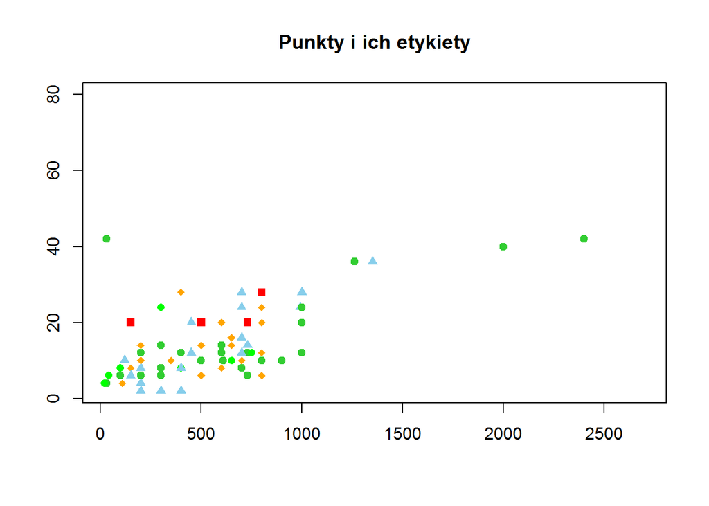

Własna implementacja:

```r
f2 <- knn(X1, y, Z, 3, 7)
f2
```

```
##   [1] 2 5 2 2 5 4 2 1 4 1 2 5 5 4 4 5 4 6 1 6 5 5 4 4 4 5 4 3 2 7 5 6 4 3 5
##  [36] 4 6 6 3 4 3 6 5 2 6 3 4 5 4 3 5 5 2 6 3 6 3 3 2 4 6 3 5 6 5 4 3 4 5 2
##  [71] 2 5 2 5 5 6 5 5 2 2 5 4 4 4 6 4 6 4 5 4 2 2 5 4 4 6 6 5 6 6
## Levels: 1 2 3 4 5 6 7
```

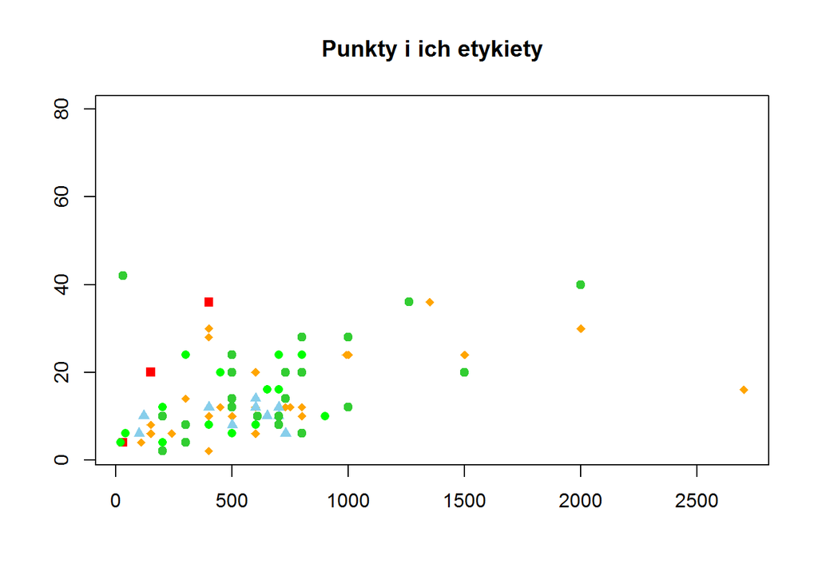

Czy wyniki funkcji są takie same: FALSE

Wyniki funkcji różnią się na 76 pozycjach (76% całości)

## 2.3 k = 9, p = 9

Funkcja referencyjna:

```r
f1 <- knn_do_porownan(X1, y, Z, 9, 9)
f1
```

```
##  [1] 4 5 5 5 5 5 3 5 5 5 5 5 3 4 3 5 4 4 6 4 4 3 5 6 4 4 5 3 2 6 5 6 5 4 5
## [36] 4 3 4 5 5 5 6 5 3 3 5 4 4 4 3 6 6 4 3 5 5 6 5 4 4 4 5 3 5 4 4 5 5 5 5
## Levels: 1 2 3 4 5 6 7
```

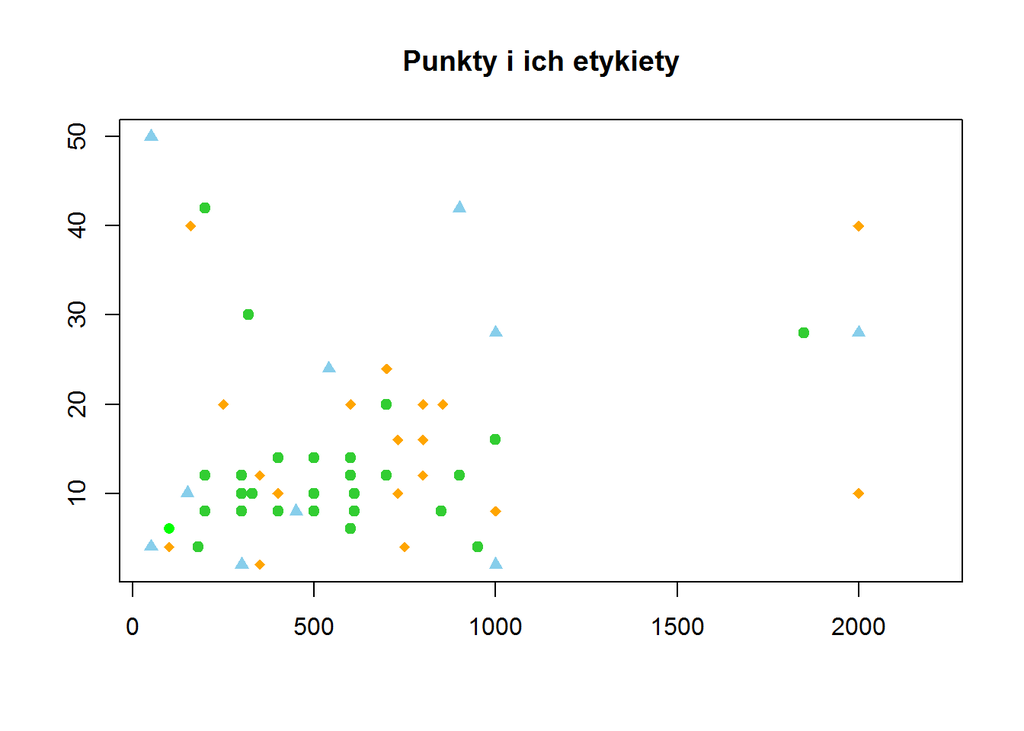

Własna implementacja:

```r
f2 <- knn(X1, y, Z, 9, 9)
f2
```

```
##  [1] 4 5 6 4 2 3 4 3 4 4 5 5 3 4 3 5 3 4 6 4 6 5 5 4 4 4 5 5 6 6 5 4 2 2 5
## [36] 6 6 3 3 5 4 5 4 3 4 5 4 4 3 3 6 6 4 3 5 6 6 5 4 6 6 5 2 3 4 4 5 4 5 5
## Levels: 1 2 3 4 5 6 7
```

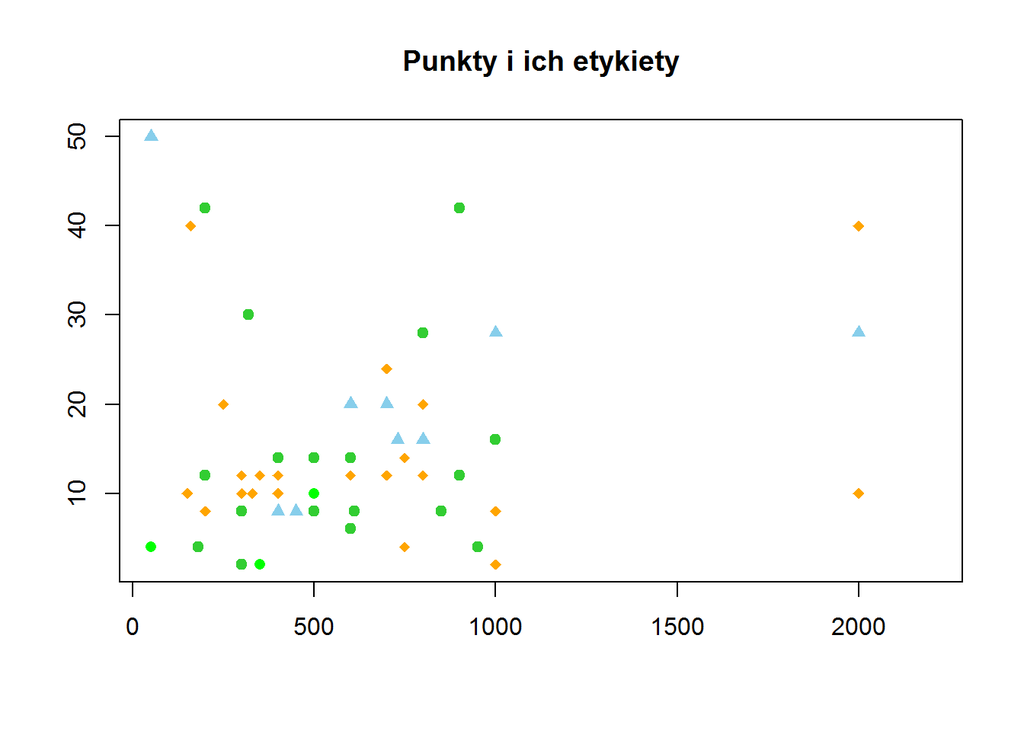

Czy wyniki funkcji są takie same: FALSE

Wyniki funkcji różnią się na 32 pozycjach (45.7142857% całości)

# 3 Glass

## 3.1 k = 1, p = 2

Zbiór uczący i testowy są takie same - w tym przypadku dla $k=1$ nie powinny występować rozbieżności między etykietami wejściowymi a obliczonymi (wyjątkowo zbiory są z $\mathbb{R}^n$).

Funkcja referencyjna:

```r
f1 <- knn_do_porownan(X, y, X, 1, 2)
head(f1, n=100)
```

```
##   [1] 1 1 1 1 1 1 1 1 1 1 1 1 1 1 1 1 1 1 1 1 1 1 1 1 1 1 1 1 1 1 1 1 1 1 1
##  [36] 1 1 1 1 1 1 1 1 1 1 1 1 1 1 1 1 1 1 1 1 1 1 1 1 1 1 1 1 1 1 1 1 1 1 2
##  [71] 2 2 2 2 2 2 2 2 2 2 2 2 2 2 2 2 2 2 2 2 2 2 2 2 2 2 2 2 2 2
## Levels: 1 2 3 4 5 6
```

Liczba różnic pomiędzy wynikiem $w$ a poprawnymi etykietami $y$ wynosi 0.

Własna implementacja:

```r
f2 <- knn(X, y, X, 1, 2)
head(f2, n=100)
```

```
##   [1] 1 1 1 1 1 1 1 1 1 1 1 1 1 1 1 1 1 1 1 1 1 1 1 1 1 1 1 1 1 1 1 1 1 1 1
##  [36] 1 1 1 1 1 1 1 1 1 1 1 1 1 1 1 1 1 1 1 1 1 1 1 1 1 1 1 1 1 1 1 1 1 1 2
##  [71] 2 2 2 2 2 2 2 2 2 2 2 2 2 2 2 2 2 2 2 2 2 2 2 2 2 2 2 2 2 2
## Levels: 1 2 3 4 5 6
```

Liczba różnic pomiędzy wynikiem $w$ a poprawnymi etykietami $y$ wynosi 0.

Czy wyniki funkcji są takie same: TRUE

Wyniki funkcji różnią się na 0 pozycjach (0% całości)

## 3.2 k = 3, p = 7

Funkcja referencyjna:

```r
f1 <- knn_do_porownan(X1, y, Z, 3, 7)
f1
```

```
##   [1] 2 1 1 2 1 1 1 1 1 1 2 2 1 1 2 1 2 1 2 1 1 1 1 1 1 1 1 1 2 2 1 2 1 2 1
##  [36] 1 1 2 1 1 1 1 1 2 2 1 1 2 1 2 1 1 1 2 1 1 2 1 1 1 1 1 1 2 2 1 2 2 1 1
##  [71] 2 1 1 1 1 1 2 1 2 1 2 1 1 2 1 2 1 2 1 2 2 1 1 1 2 2 2 1 1 1
## Levels: 1 2 3 4 5 6
```

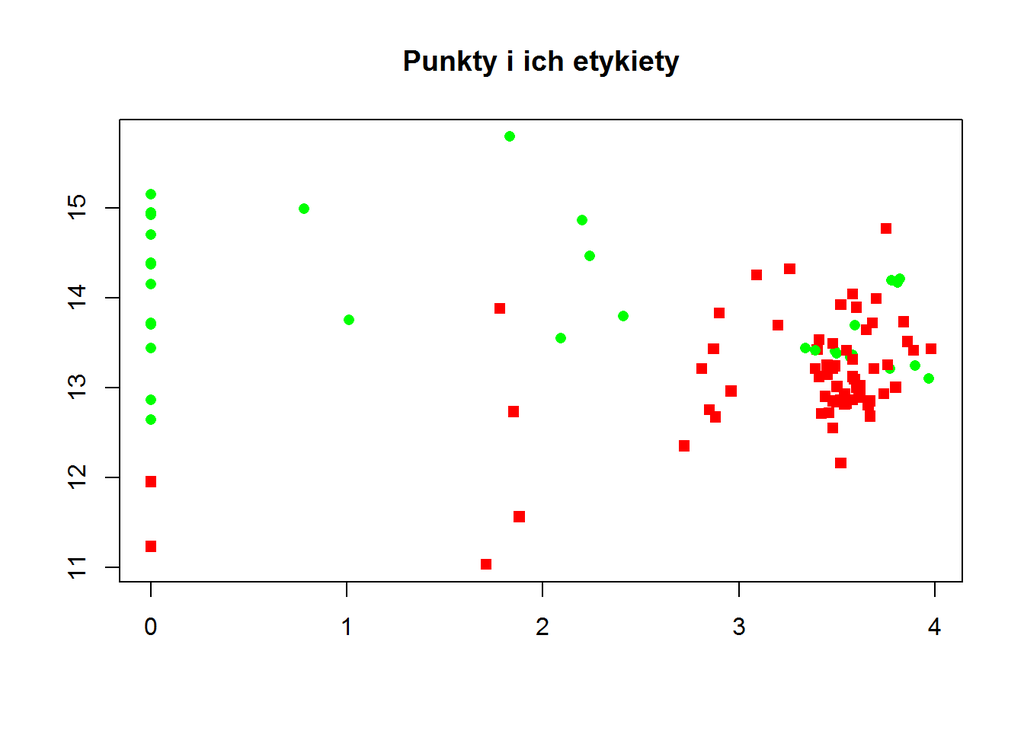

Własna implementacja:

```r
f2 <- knn(X1, y, Z, 3, 7)
f2
```

```
##   [1] 2 1 1 2 1 1 1 1 1 1 2 2 1 1 2 1 2 1 2 1 1 1 1 1 1 1 1 1 2 2 1 2 1 2 1
##  [36] 1 1 2 1 1 1 1 1 2 2 1 1 2 1 2 1 1 1 2 1 1 2 1 1 1 1 1 1 2 2 1 2 2 1 1
##  [71] 2 1 1 1 1 1 2 1 2 1 2 1 1 2 1 2 1 2 1 2 2 1 1 1 2 2 2 1 1 1
## Levels: 1 2 3 4 5 6
```

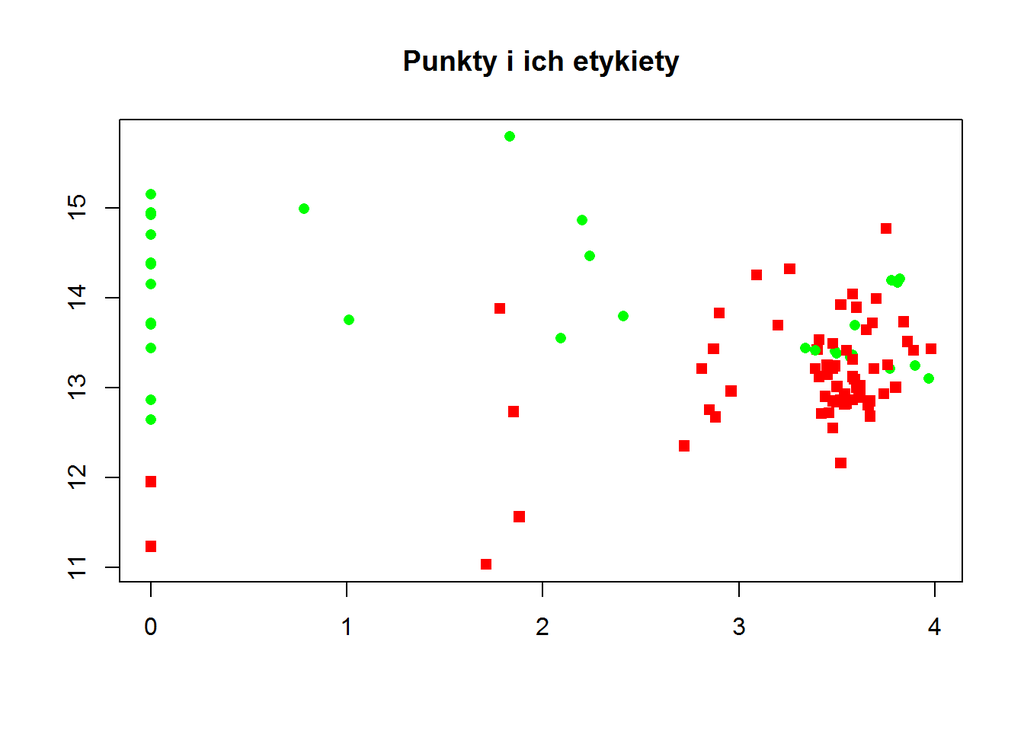

Czy wyniki funkcji są takie same: TRUE

Wyniki funkcji różnią się na 0 pozycjach (0% całości)

## 3.3 k = 9, p = 9

Funkcja referencyjna:

```r
f1 <- knn_do_porownan(X1, y, Z, 9, 9)
f1
```

```
##  [1] 2 2 2 1 2 1 2 1 1 2 2 1 2 1 1 1 2 2 1 1 2 1 2 2 1 2 1 2 1 1 1 2 2 1 1
## [36] 2 2 1 1 2 1 2 1 1 1 2 1 2 1 1 1 2 2 1 1 2 1 1 1 1 1 1 2 1 1 2 1 2 2 2
## Levels: 1 2 3 4 5 6
```

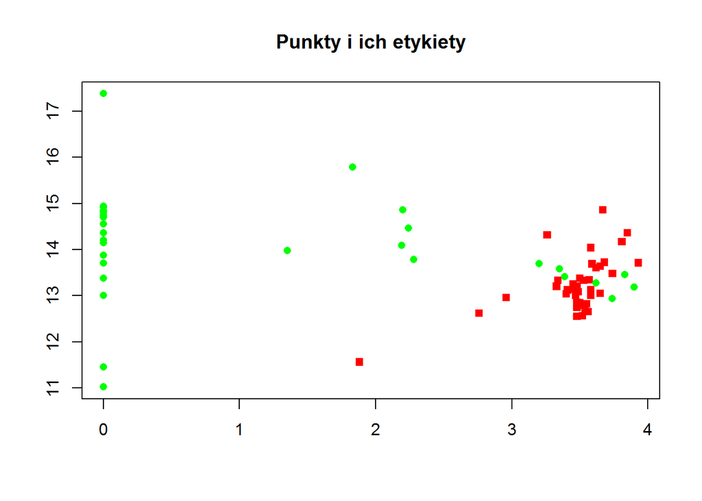

Własna implementacja:

```r
f2 <- knn(X1, y, Z, 9, 9)
f2
```

```
##  [1] 2 2 2 1 2 1 2 1 1 2 2 1 2 1 1 1 2 2 1 1 2 1 2 2 1 2 1 2 1 1 1 2 2 1 1
## [36] 2 2 1 1 2 1 2 1 1 1 2 1 2 1 1 1 2 2 1 1 2 1 1 1 1 1 1 2 1 1 2 1 2 2 2
## Levels: 1 2 3 4 5 6
```

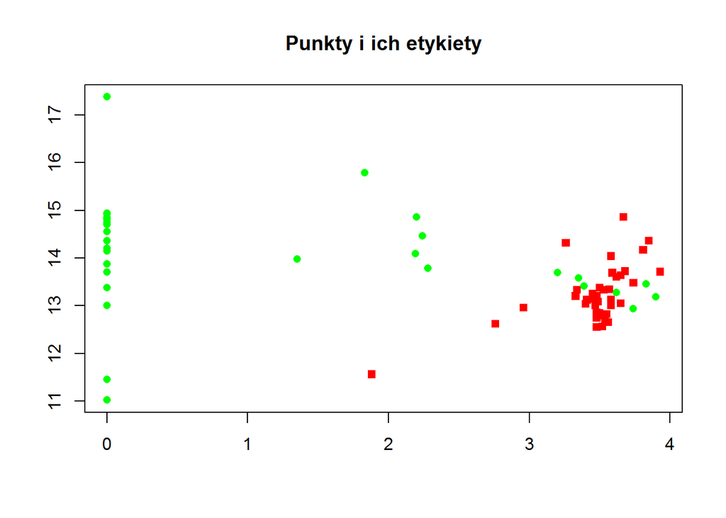

Czy wyniki funkcji są takie same: TRUE

Wyniki funkcji różnią się na 0 pozycjach (0% całości)